# Behavioural Data

## The Forssmann Situation

Response times for no go trials show a weird pattern. Usually, any response time > 1.5 s should be correct (reward), anything below should be incorrect (punishment).

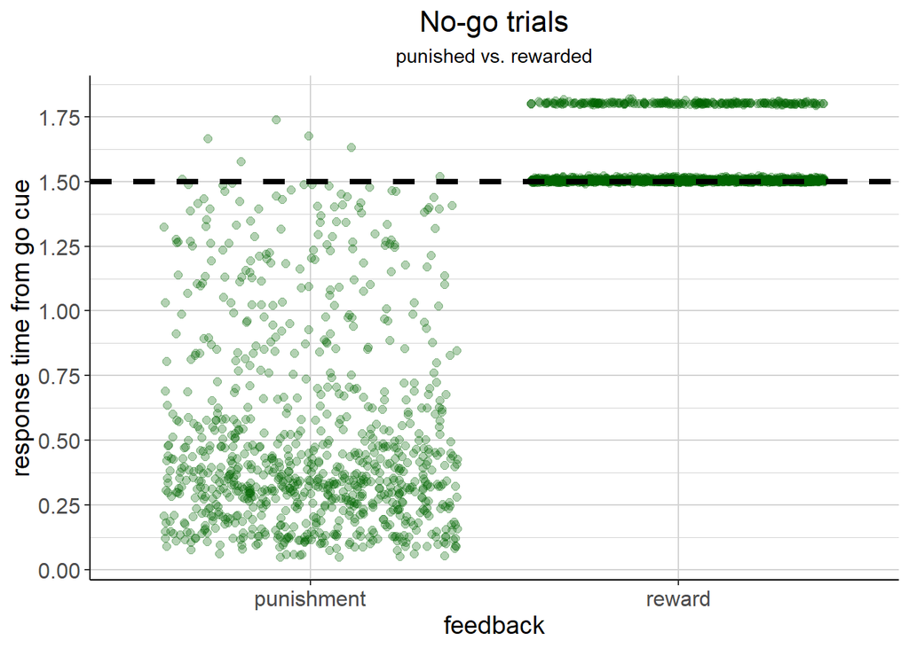

The same strange pattern occurs for no-go responses in go trials.

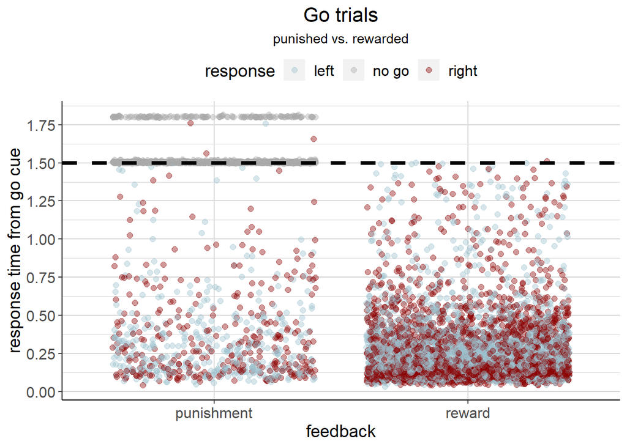

We can find out where the two distinct populations of no-go response times are coming from by figuring out when which type (low is < 1.7 s; high is > 1.7 s) occurs when.

Turns out, no-go responses > 1.7 s are associated with one mouse, Forssmann.

| response time | mouse | count |
| --- | --- | --- |
| high | Forssmann | 384 |
| low | Cori | 245 |
| low | Hench | 479 |
| low | Lederberg | 480 |
| low | Moniz | 262 |
| low | Muller | 263 |
| low | Radnitz | 334 |
| low | Richards | 440 |
| low | Tatum | 308 |
| low | Theiler | 110 |

The weird response times occur in sessions 4, 5, 6 and 7, which are all Forssmann’s sessions.

| response time | session | count |
| --- | --- | --- |
| high | 4 | 126 |
| high | 5 | 104 |
| high | 6 | 92 |
| high | 7 | 62 |
| low | 1 | 74 |
| low | 2 | 94 |

Indeed, Forssmann is the culprit. We take him out from now on, since his timing will be messed up.

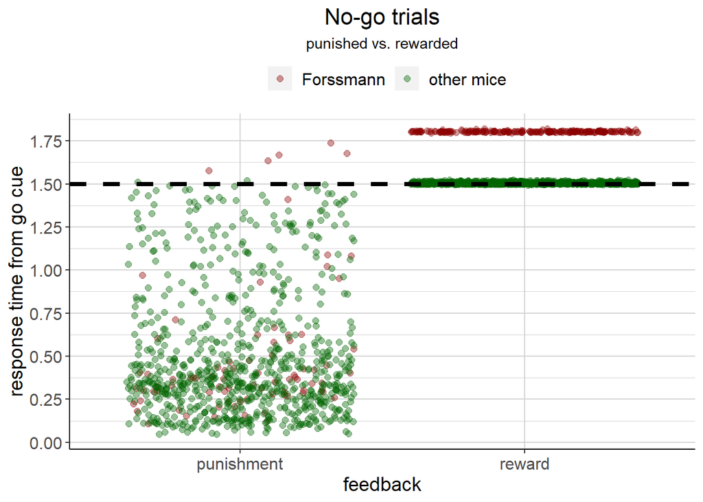

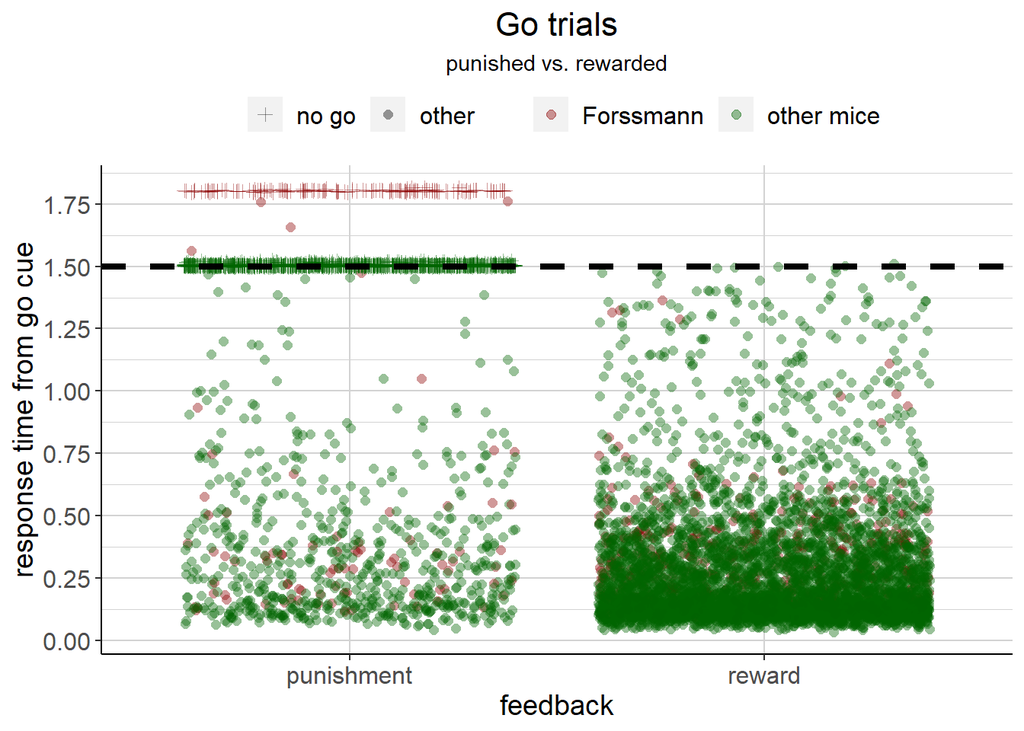

## The Lederberg Situation

Lederberg had a very different neural response from the others, which is why we excluded him from the analysis. However, we briefly want to look at his behavioural data, since he seems to be a very smart mouse. Here are his response times, as compared to the other mice. He seems to be consistently fast for correct responses. And doesn’t seem to make any mistakes (except for no-go responses) at a contrast difference of one.

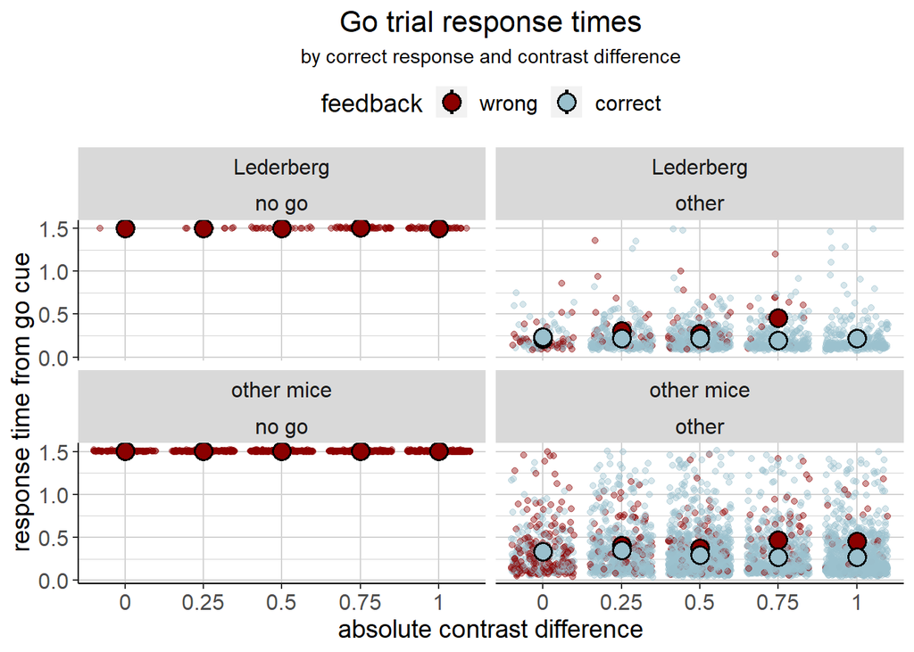

We can also look at his performance (see a detailed description of the plot below). He makes less errors overall. If he makes errors, they are less likely to be no-go responses. He basically always goes for it :-) We may have excluded him, but we would like to honour the smartes mouse in the data set here.

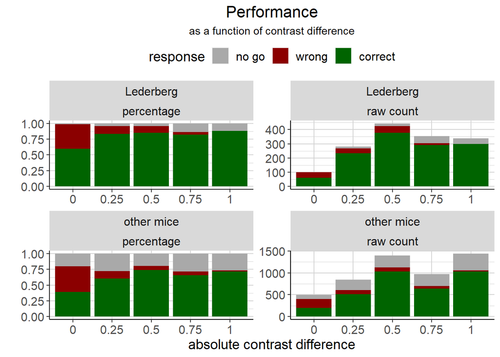

## General stuff

Different contrasts and conditions are not distributed evenly.

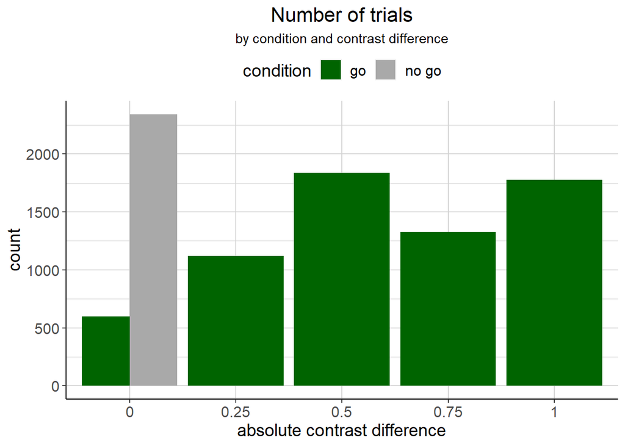

## Response times

We look at go trial response times first. For no-go responses (which are always wrong in a go trial), response times are of course always the same (1.5 s). For go responses that mice got correct, response times seem to get slightly shorter as the contrast difference increases (i.e. as trials get easier). For go responses that the mice got wrong (i.e. where they made a response, but chose the wrong side), response times seem to increase as the contrast difference increases. Thus, an error in an easy trial is likely to be slow, while it is faster in more difficult trials.

Note, however, that the mice got only very few trials wrong (i.e. made a response in the wrong direction) when the absolute contrast difference was 1 (i.e. there was only one stimulus shown): 33 out of 1778 trials with an absolute contrast of 1. Opposed to that, mice made 418 no-go responses out of 1778 trials with an absolute contrast of 1. That means, response times for wrong choices are probably not that meaningful for those trials.

Also note that there was no correct response for go trials with a contrast of 0. If the mouse made a go response, feedback was probabilistic. If the mouse made a no-go response, it was punished.

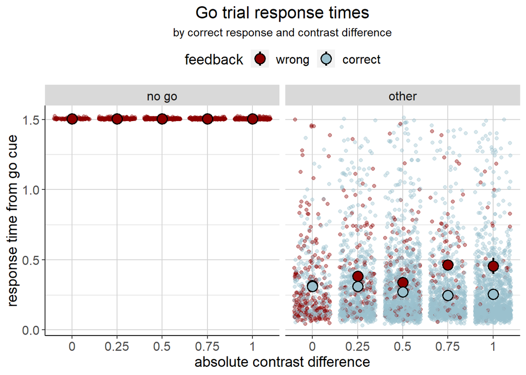

## Performance

We want to look at the performance during go trials as a function of absolute contrast difference. That is, we want to see how often the mice got it correct or wrong and how often they made a no-go response. We need to take into account that there were different numbers of trials per contrast difference, so the data are shown as raw counts and as percentages.

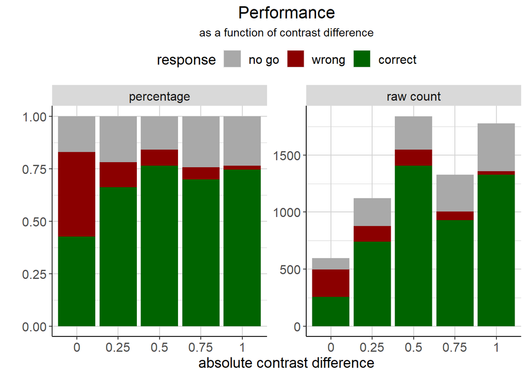